# White Wine Quality by Abbas A. Alali

> The dataset that i will be using in this exploratory data analysis process  
> is the White Wine dataset which is public available for research.

> The details are described in [Cortez et al., 2009].

> ```
> P. Cortez, A. Cerdeira, F. Almeida, T. Matos and J. Reis. Modeling wine\
> preferences by data mining from physicochemical properties. \
> In Decision Support Systems, Elsevier,47(4):547-553. ISSN: 0167-9236.
>
> Available at:
>
> [@Elsevier](http://dx.doi.org/10.1016/j.dss.2009.05.016)
>
> [Pre-press (pdf)](http://www3.dsi.uminho.pt/pcortez/winequality09.pdf)
>
> [bib](http://www3.dsi.uminho.pt/pcortez/dss09.bib)
> ```

> The dataset used has been downloaded from [this link](https://www.google.com/url?q=https://s3.amazonaws.com/udacity-hosted-down%20loads/ud651/wineQualityWhites.csv&sa=D&ust=1518211607164000&usg=AFQjCNGqcmTIF2%20an-RHraAjbtMBpAhsdTg)

# Univariate Plots Section

## *Preliminary Exploration:*

```
## [1] 4898   13
```

```
## 'data.frame':    4898 obs. of  13 variables:
##  $ X                   : int  1 2 3 4 5 6 7 8 9 10 ...
##  $ fixed.acidity       : num  7 6.3 8.1 7.2 7.2 8.1 6.2 7 6.3 8.1 ...
##  $ volatile.acidity    : num  0.27 0.3 0.28 0.23 0.23 0.28 0.32 0.27 0.3 0.22 ...
##  $ citric.acid         : num  0.36 0.34 0.4 0.32 0.32 0.4 0.16 0.36 0.34 0.43 ...
##  $ residual.sugar      : num  20.7 1.6 6.9 8.5 8.5 6.9 7 20.7 1.6 1.5 ...
##  $ chlorides           : num  0.045 0.049 0.05 0.058 0.058 0.05 0.045 0.045 0.049 0.044 ...
##  $ free.sulfur.dioxide : num  45 14 30 47 47 30 30 45 14 28 ...
##  $ total.sulfur.dioxide: num  170 132 97 186 186 97 136 170 132 129 ...
##  $ density             : num  1.001 0.994 0.995 0.996 0.996 ...
##  $ pH                  : num  3 3.3 3.26 3.19 3.19 3.26 3.18 3 3.3 3.22 ...
##  $ sulphates           : num  0.45 0.49 0.44 0.4 0.4 0.44 0.47 0.45 0.49 0.45 ...
##  $ alcohol             : num  8.8 9.5 10.1 9.9 9.9 10.1 9.6 8.8 9.5 11 ...
##  $ quality             : int  6 6 6 6 6 6 6 6 6 6 ...
```

```
##        X        fixed.acidity    volatile.acidity  citric.acid
##  Min.   :   1   Min.   : 3.800   Min.   :0.0800   Min.   :0.0000
##  1st Qu.:1225   1st Qu.: 6.300   1st Qu.:0.2100   1st Qu.:0.2700
##  Median :2450   Median : 6.800   Median :0.2600   Median :0.3200
##  Mean   :2450   Mean   : 6.855   Mean   :0.2782   Mean   :0.3342
##  3rd Qu.:3674   3rd Qu.: 7.300   3rd Qu.:0.3200   3rd Qu.:0.3900
##  Max.   :4898   Max.   :14.200   Max.   :1.1000   Max.   :1.6600
##  residual.sugar     chlorides       free.sulfur.dioxide
##  Min.   : 0.600   Min.   :0.00900   Min.   :  2.00
##  1st Qu.: 1.700   1st Qu.:0.03600   1st Qu.: 23.00
##  Median : 5.200   Median :0.04300   Median : 34.00
##  Mean   : 6.391   Mean   :0.04577   Mean   : 35.31
##  3rd Qu.: 9.900   3rd Qu.:0.05000   3rd Qu.: 46.00
##  Max.   :65.800   Max.   :0.34600   Max.   :289.00
##  total.sulfur.dioxide    density             pH          sulphates
##  Min.   :  9.0        Min.   :0.9871   Min.   :2.720   Min.   :0.2200
##  1st Qu.:108.0        1st Qu.:0.9917   1st Qu.:3.090   1st Qu.:0.4100
##  Median :134.0        Median :0.9937   Median :3.180   Median :0.4700
##  Mean   :138.4        Mean   :0.9940   Mean   :3.188   Mean   :0.4898
##  3rd Qu.:167.0        3rd Qu.:0.9961   3rd Qu.:3.280   3rd Qu.:0.5500
##  Max.   :440.0        Max.   :1.0390   Max.   :3.820   Max.   :1.0800
##     alcohol         quality
##  Min.   : 8.00   Min.   :3.000
##  1st Qu.: 9.50   1st Qu.:5.000
##  Median :10.40   Median :6.000
##  Mean   :10.51   Mean   :5.878
##  3rd Qu.:11.40   3rd Qu.:6.000
##  Max.   :14.20   Max.   :9.000
```

### *Quality:*

The quality of wine varies from 3 to 9 in our dataset. There are no 0 or 10  
rated wine in the dataset, the minimum rated wine is 3 and the maximum is 9.  
The median quality is 6

```
##
##    3    4    5    6    7    8    9
##   20  163 1457 2198  880  175    5
```

```
##    Min. 1st Qu.  Median    Mean 3rd Qu.    Max.
##   3.000   5.000   6.000   5.878   6.000   9.000
```

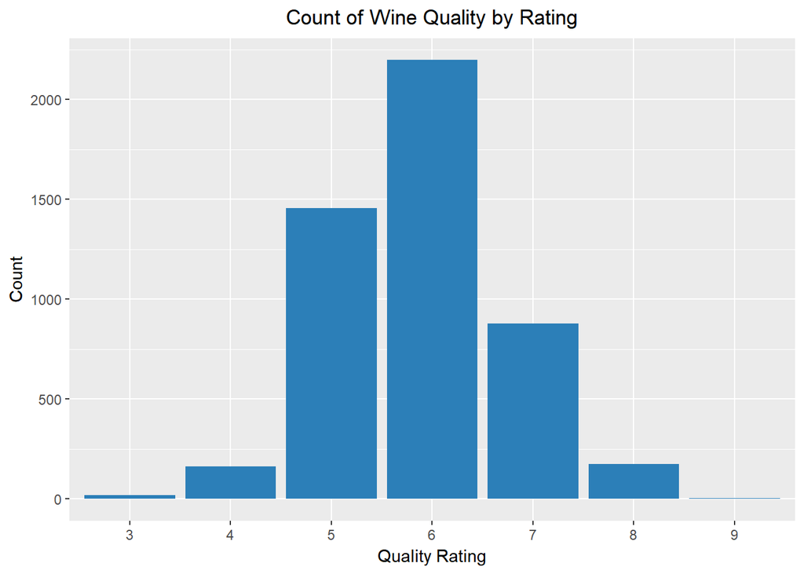

From the summary of the ratings and the plot above, we can see that there are  
very few wine records that are rated as 3 or 9 (25 records out of the  
whole dataset).These records might be excluded from future analysis and plots  
as they will be outliers.

Also, a new variable has been created to bucket the rating as Low(3-4),  
Medium(5-7), high(8-9)

### *Fixed Acidity:*

```
##    Min. 1st Qu.  Median    Mean 3rd Qu.    Max.
##   3.800   6.300   6.800   6.855   7.300  14.200
```

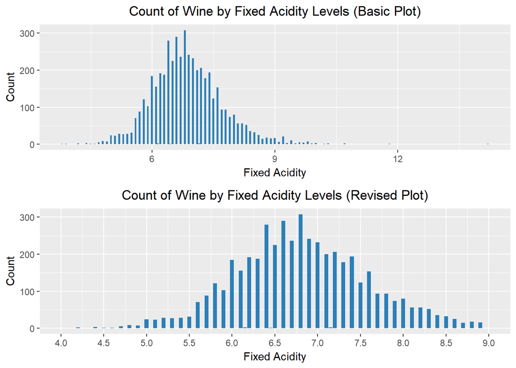

The fixed acidity plot looks normally distributed with mean value of (6.855).  
After several adjustments to the x-axis scale, most of the wines are ranged from  
5.5 to 8.5 fixed acidity level

### *Volatile Acidity:*

```
##    Min. 1st Qu.  Median    Mean 3rd Qu.    Max.
##  0.0800  0.2100  0.2600  0.2782  0.3200  1.1000
```

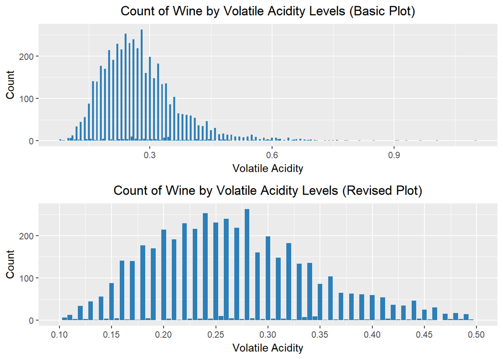

With the basic plot of the volatile acidity levels, I can see that most of  
the wine records is ranged from 0.08 to 1.1 acidity levels with (0.2782)  
mean value . After several adjustments to the x-axis scale, most of the wines  
are ranged from 0.15 to 0.40 volatile acidity level

### *Citric Acid:*

```
##    Min. 1st Qu.  Median    Mean 3rd Qu.    Max.
##  0.0000  0.2700  0.3200  0.3342  0.3900  1.6600
```

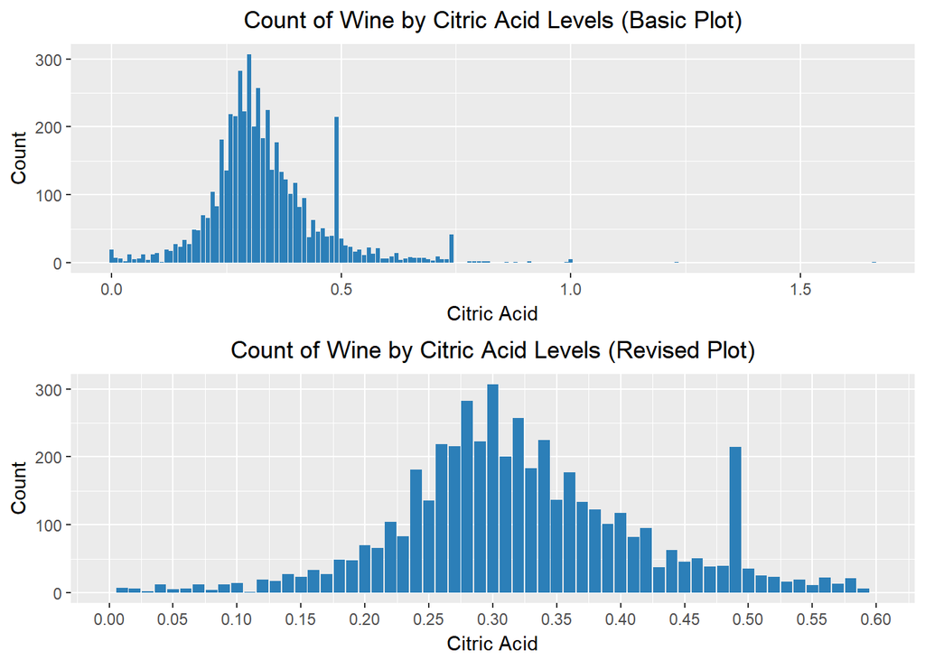

The basic plot of the citric acidity shows that the wine records is ranged  
from 0 to 1.6 acidity levels with mean value of (0.3342). After several  
adjustments to the x-axis scale, most of the wines are ranged from 0.15 to 0.50  
citric acidity level

### *Residual Sugar:*

```
##    Min. 1st Qu.  Median    Mean 3rd Qu.    Max.
##   0.600   1.700   5.200   6.391   9.900  65.800
```

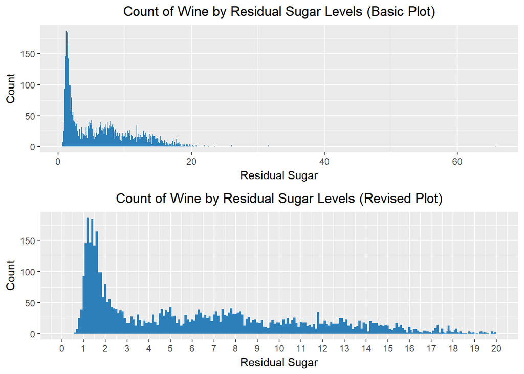

The basic plot of the residual sugar shows that the wine records is ranged  
from 0.6 to 65.8 residual sugar levels (which is considered to be a very wide range)  
with mean value of (6.391). After several adjustments to the x-axis scale,  
most of the wines are ranged from 0.5 to 20 residual sugar level

### *Chlorides:*

```
##    Min. 1st Qu.  Median    Mean 3rd Qu.    Max.
## 0.00900 0.03600 0.04300 0.04577 0.05000 0.34600
```

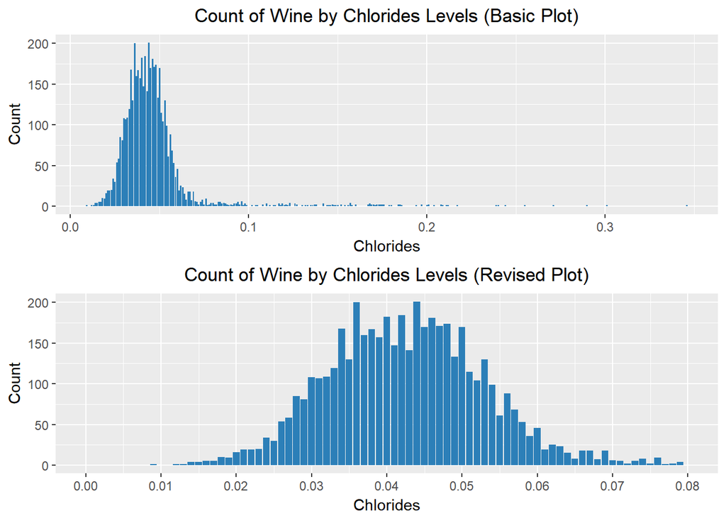

The basic plot of the chlorides shows that the wine records is ranged  
from 0 to 0.346 chlorides levels with mean value of (0.04577). After several  
adjustments to the x-axis scale, most of the wines are ranged  
from 0.025 to 0.065 chlorides level

### *Free Sulfur Dioxide:*

```
##    Min. 1st Qu.  Median    Mean 3rd Qu.    Max.
##    2.00   23.00   34.00   35.31   46.00  289.00
```

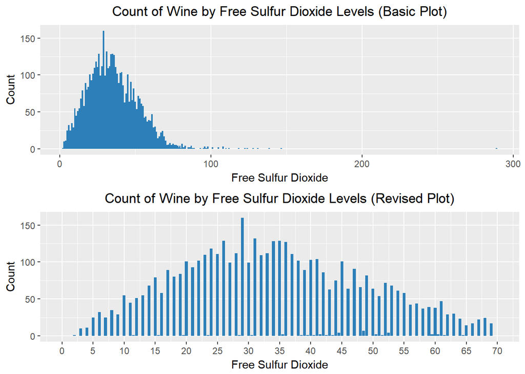

The basic plot of the free sulfur dioxide shows that the wine records is  
ranged from 2 to 289 free sulfur dioxide levels with mean value of (35.31).  
After several adjustments to the x-axis scale, most of the wines are ranged  
from 10 to 60 free sulfur dioxide level

### *Total Sulfur Dioxide:*

```
##    Min. 1st Qu.  Median    Mean 3rd Qu.    Max.
##     9.0   108.0   134.0   138.4   167.0   440.0
```

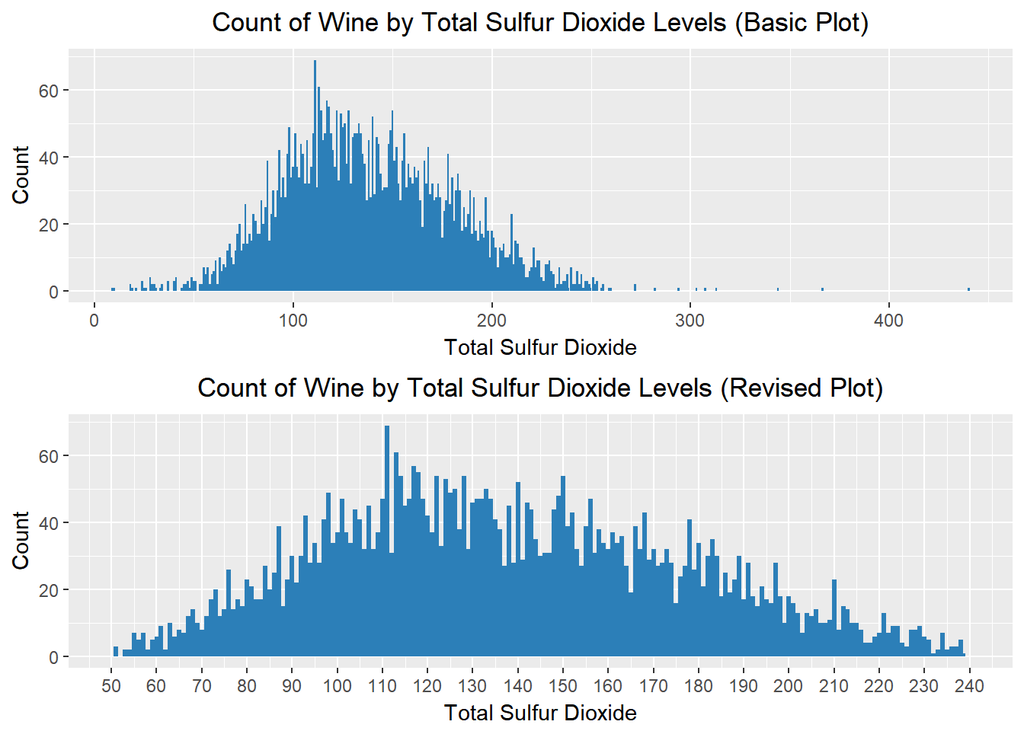

The basic plot of the total sulfur dioxide shows that the wine records is  
ranged from 9 to 440 total sulfur dioxide levels (which is considered to be  
a very wide range) with mean value of (138.4). After several adjustments to  
the x-axis scale, most of the wines are ranged from 60 to 220 total sulfur  
dioxide level

### *Density:*

```
##    Min. 1st Qu.  Median    Mean 3rd Qu.    Max.
##  0.9871  0.9917  0.9937  0.9940  0.9961  1.0390
```

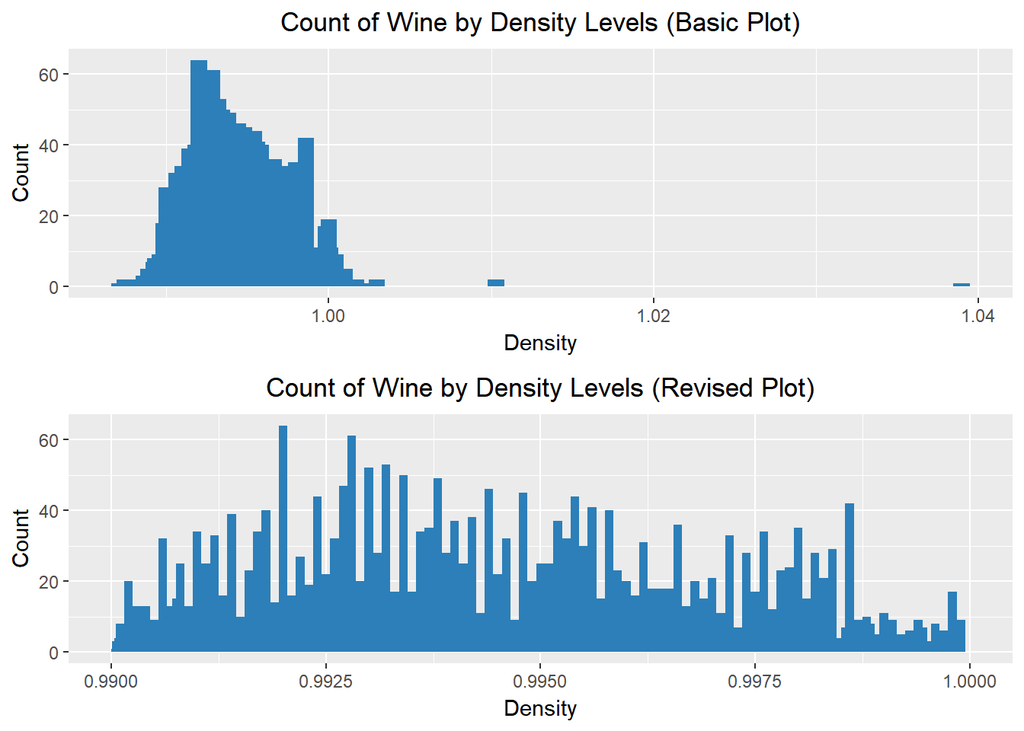

The basic plot of the density shows that the wine records is ranged  
from 0.98 to 1.039 density levels with mean value of (0.9940). After several  
adjustments to the x-axis scale, most of the wines are ranged  
from 0.9910 to 0.9980 density level

### *PH:*

```
##    Min. 1st Qu.  Median    Mean 3rd Qu.    Max.
##   2.720   3.090   3.180   3.188   3.280   3.820
```

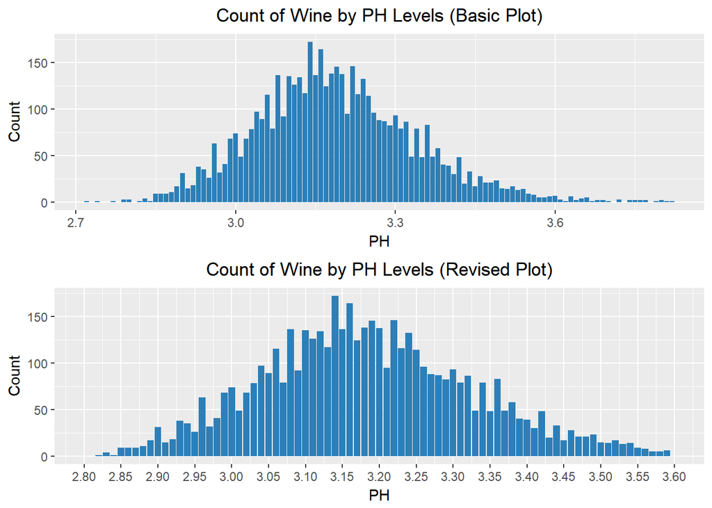

The basic plot of the PH shows that the wine records is ranged  
from 2.72 to 3.82 density levels with mean value of (3.188). After several  
adjustments to the x-axis scale, most of the wines are ranged  
from 2.9 to 3.45 PH level

### *Sulphates:*

```
##    Min. 1st Qu.  Median    Mean 3rd Qu.    Max.
##  0.2200  0.4100  0.4700  0.4898  0.5500  1.0800
```

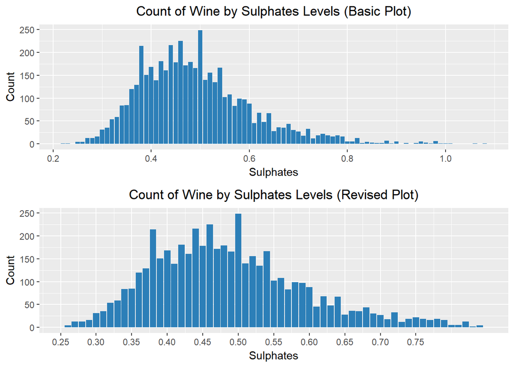

The basic plot of the Sulphates shows that the wine records is ranged  
from 0.22 to 1.08 density levels with mean value of (0.4898). After several  
adjustments to the x-axis scale, most of the wines are ranged  
from 0.30 to 0.70 Sulphates level

### *Alcohol:*

```
##    Min. 1st Qu.  Median    Mean 3rd Qu.    Max.
##    8.00    9.50   10.40   10.51   11.40   14.20
```

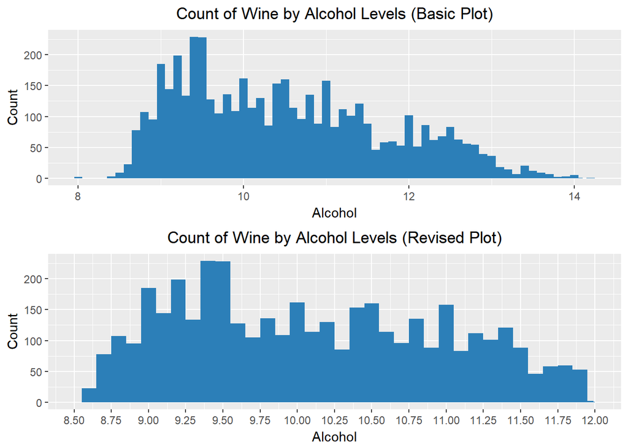

The basic plot of the Alcohol shows that the wine records is ranged  
from 8 to 14.20 alcohol levels with mean value of (10.51). After several  
adjustments to the x-axis scale, most of the wines are ranged  
from 8.6 to 11.8 alcohol level

# Univariate Analysis

### What is the structure of your dataset?

**The dataset explored contains (4898) white wine quality records of 13 variables for each record**

### Description of dataset attributes:

| Attribute Number | Attribute | Description |
| --- | --- | --- |
| 1 | X | Record number in the dataset |
| 2 | fixed acidity | Most acids involved with wine or fixed or nonvolatile (do not evaporate readily) |
| 3 | volatile acidity | The amount of acetic acid in wine, which at too high of levels can lead to an unpleasant, vinegar taste |
| 4 | citric acid | Found in small quantities, citric acid can add ‘freshness’ and flavor to wines |
| 5 | residual sugar | The amount of sugar remaining after fermentation stops, it’s rare to find wines with less than 1 gram/liter and wines with greater than 45 grams/liter are considered sweet |
| 6 | chlorides | The amount of salt in the wine |
| 7 | free sulfur dioxide | The free form of SO2 exists in equilibrium between molecular SO2 (as a dissolved gas) and bisulfite ion; it prevents microbial growth and the oxidation of wine |
| 8 | total sulfur dioxide | Amount of free and bound forms of S02; in low concentrations, SO2 is mostly undetectable in wine, but at free SO2 concentrations over 50 ppm, SO2 becomes evident in the nose and taste of wine |
| 9 | Density | The density of water is close to that of water depending on the percent alcohol and sugar content |
| 10 | pH | Describes how acidic or basic a wine is on a scale from 0 (very acidic) to 14 (very basic); most wines are between 3-4 on the pH scale |
| 11 | sulphates | A wine additive which can contribute to sulfur dioxide gas (S02) levels, wich acts as an antimicrobial and antioxidant |
| 12 | alcohol | The percent alcohol content of the wine |
| 13 | quality | (score between 0 and 10) |

### What is/are the main feature(s) of interest in your dataset?

The main feature in the dataset that i think will help supporting my  
investigation is Quality:

The quality in our dataset is the score given to record of wine (0 - 10)  
where 0 is very bad and 10 is very excellent. It is the main feature of  
investigation since the rating has been given by at least 3 wine experts

### What other features in the dataset do you think will help support your investigation into your feature(s) of interest?

Other features of investigations will the characterstics of wine compared  
with qualilty which are:

[output not shown]

### Did you create any new variables from existing variables in the dataset?

Yes I did create (2) new variables to store the rating levels into  
(quality.rating).The other new variable is (rating) to categorize ratings  
as High[8-9], Meduim[5-7], and Low[3-4].

### Of the features you investigated, were there any unusual distributions? Did you perform any operations on the data to tidy, adjust, or change the form of the data? If so, why did you do this?

The residual sugar and total sulfur dioxide looked unsual which had a very  
wide range of distribution. Both plots were adjusted to show the majorirty of  
data distribution of each feature. The reason to perform such adjustement is to  
exclude outliers from the plots.

# Bivariate Plots Section

```
##                      fixed.acidity volatile.acidity citric.acid
## fixed.acidity           1.00000000      -0.02644285  0.29007165
## volatile.acidity       -0.02644285       1.00000000 -0.15097877
## citric.acid             0.29007165      -0.15097877  1.00000000
## residual.sugar          0.08813887       0.06468325  0.09491715
## chlorides               0.02150035       0.06451051  0.11453271
## free.sulfur.dioxide    -0.04759734      -0.10163420  0.10376956
## total.sulfur.dioxide    0.09331658       0.08609712  0.12623026
## density                 0.26464526       0.02588518  0.15047198
## pH                     -0.42385864      -0.03062974 -0.16387143
## sulphates              -0.01590932      -0.03747128  0.06324175
## alcohol                -0.12187370       0.06843093 -0.07718465
## quality                -0.10850037      -0.19454075 -0.01086724
##                      residual.sugar   chlorides free.sulfur.dioxide
## fixed.acidity            0.08813887  0.02150035        -0.047597338
## volatile.acidity         0.06468325  0.06451051        -0.101634197
## citric.acid              0.09491715  0.11453271         0.103769558
## residual.sugar           1.00000000  0.08675170         0.313353952
## chlorides                0.08675170  1.00000000         0.105536504
## free.sulfur.dioxide      0.31335395  0.10553650         1.000000000
## total.sulfur.dioxide     0.40548981  0.19671493         0.610845745
## density                  0.83960009  0.25566780         0.306361342
## pH                      -0.19237918 -0.08661660        -0.007356387
## sulphates               -0.02835738  0.01203111         0.057667223
## alcohol                 -0.45196068 -0.36036561        -0.258717534
## quality                 -0.09901097 -0.20960722         0.024182556
##                      total.sulfur.dioxide     density           pH
## fixed.acidity                 0.093316581  0.26464526 -0.423858637
## volatile.acidity              0.086097117  0.02588518 -0.030629735
## citric.acid                   0.126230259  0.15047198 -0.163871429
## residual.sugar                0.405489810  0.83960009 -0.192379177
## chlorides                     0.196714934  0.25566780 -0.086616596
## free.sulfur.dioxide           0.610845745  0.30636134 -0.007356387
## total.sulfur.dioxide          1.000000000  0.53425291  0.001717477
## density                       0.534252905  1.00000000 -0.090886254
## pH                            0.001717477 -0.09088625  1.000000000
## sulphates                     0.131604183  0.07282078  0.157146280
## alcohol                      -0.453861050 -0.78047187  0.120173392
## quality                      -0.169875016 -0.30983715  0.099748998
##                        sulphates     alcohol     quality
## fixed.acidity        -0.01590932 -0.12187370 -0.10850037
## volatile.acidity     -0.03747128  0.06843093 -0.19454075
## citric.acid           0.06324175 -0.07718465 -0.01086724
## residual.sugar       -0.02835738 -0.45196068 -0.09901097
## chlorides             0.01203111 -0.36036561 -0.20960722
## free.sulfur.dioxide   0.05766722 -0.25871753  0.02418256
## total.sulfur.dioxide  0.13160418 -0.45386105 -0.16987502
## density               0.07282078 -0.78047187 -0.30983715
## pH                    0.15714628  0.12017339  0.09974900
## sulphates             1.00000000 -0.01596332  0.05430828
## alcohol              -0.01596332  1.00000000  0.44280807
## quality               0.05430828  0.44280807  1.00000000
```

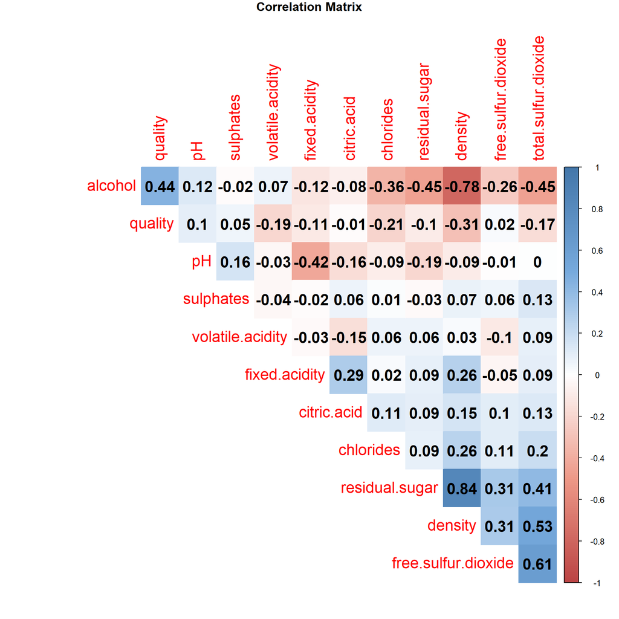

# Bivariate Analysis

### Talk about some of the relationships you observed in this part of the investigation. How did the feature(s) of interest vary with other features in the dataset?

My main feature of interest is the quality and from the correlation plot  
matrix, the only noticable positive correlcation between quality and other  
features is alcohol vs quality relationship. There is a positive correlation  
of 0.44 between quality and alcohol, which means that the more alcohol the  
better quality of wine.

### Did you observe any interesting relationships between the other features (not the main feature(s) of interest)?

From the correlation plot matrix, I can see that there is a very strong  
positive correlation of 0.84 betwen density and residual sugar. On the other  
hand, there is negative correlation of 0.78 between density and alcohol.

### What was the strongest relationship you found?

The strongest relationship between the features of white wine is found  
between density and residual sugar. The correlation between the two features  
is +0.84.

# Multivariate Plots Section

### *Alcohol VS. Quality (Main Feature of Interest)*

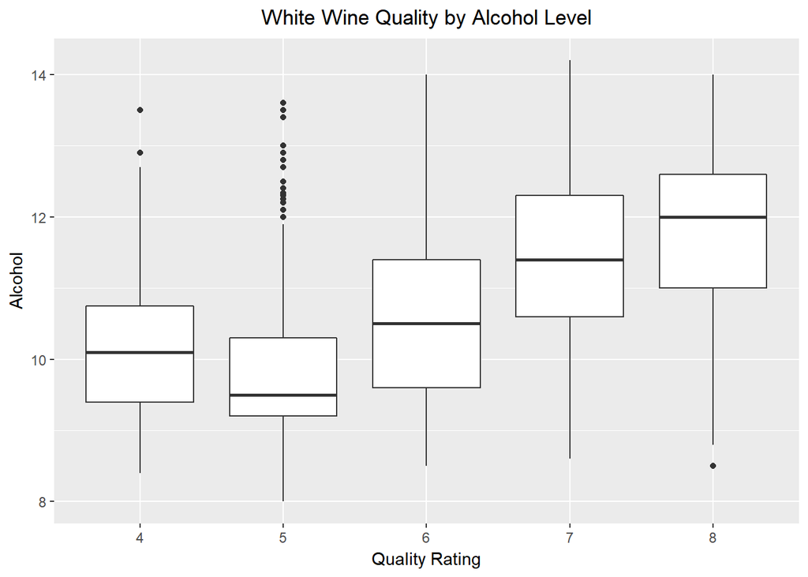

### *Density VS. Residual Sugar (Other features of Interests)*

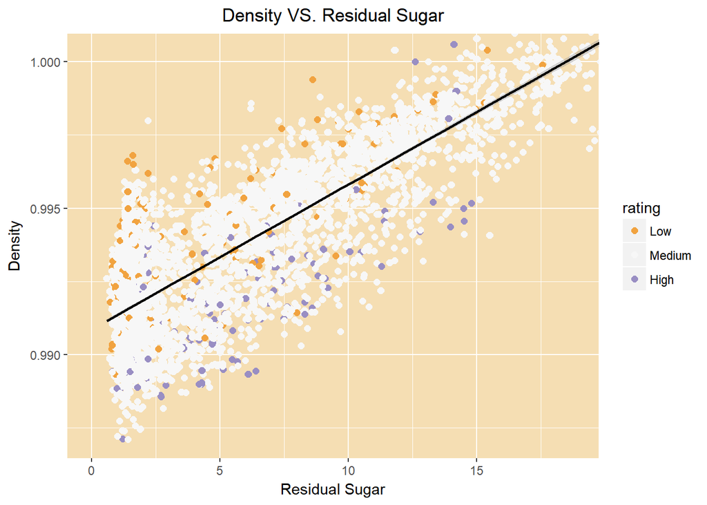

### *Density VS. Alcohol (Other features of Interests)*

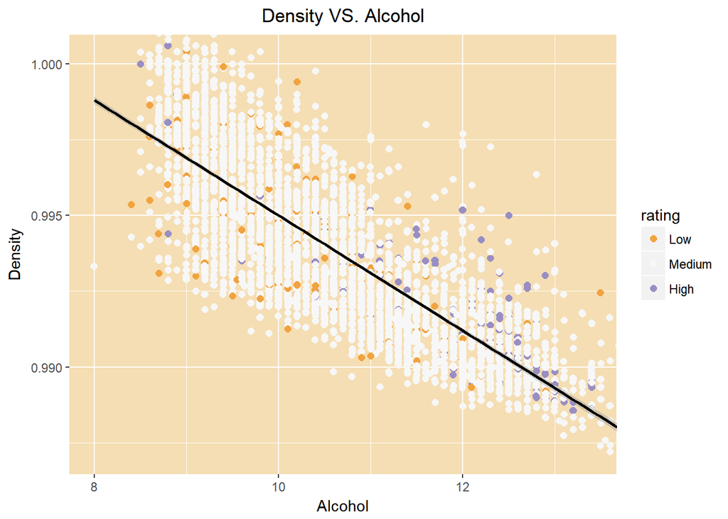

### *Linear Model Regression*

```
##
## Call:
## lm(formula = quality ~ alcohol + residual.sugar + density, data = wdf)
##
## Residuals:
##     Min      1Q  Median      3Q     Max
## -3.5173 -0.5368 -0.0093  0.4739  3.1870
##
## Coefficients:
##                 Estimate Std. Error t value Pr(>|t|)
## (Intercept)     90.31292   12.37418   7.298 3.38e-13 ***
## alcohol          0.24587    0.01825  13.474  < 2e-16 ***
## residual.sugar   0.05332    0.00509  10.476  < 2e-16 ***
## density        -87.88589   12.31680  -7.135 1.11e-12 ***
## ---
## Signif. codes:  0 '***' 0.001 '**' 0.01 '*' 0.05 '.' 0.1 ' ' 1
##
## Residual standard error: 0.7873 on 4894 degrees of freedom
## Multiple R-squared:  0.2102, Adjusted R-squared:  0.2097
## F-statistic: 434.1 on 3 and 4894 DF,  p-value: < 2.2e-16
```

# Multivariate Analysis

### Talk about some of the relationships you observed in this part of the investigation. Were there features that strengthened each other in terms of looking at your feature(s) of interest?

From the plot “White Wine Quality by Alcohol Level”, I can see that the  
quality of wine gets better with alcohol level greater than 9.5 (for 5+ rating)

### Were there any interesting or surprising interactions between features?

Another area of interest was to see the relationship between density and  
residual sugar since there is a strong positive correlation between the  
two features.

From the plot “Density VS. Residual Sugar”, there is a linear relationship  
between the density and residual sugar. The higher the density, there is higher  
sugar exist in white wine.

However, I have noticed a very intersting insight from the same plot which  
is that most of the high quality of wine has less density and hense  
less residual sugar.

As for the plot “Density VS. Alcohol”, it is very clear that higher alcohol  
levels are associated with lower density levels.

### OPTIONAL: Did you create any models with your dataset? Discuss the strengths and limitations of your model.

Yes I did create a linear regression model to predict the quality of wine  
with multiple variables (alcohol, residual sugar, and density)

The R-squared value generated by the model is 0.21. This means that  
about 21% of wine quality is due to the levels of alcohol, residual sugar,  
and density. The generated model is weak and indicates that there are other  
factors that affect the quality of wine other than the 3 features  
tested in the model.

# Final Plots and Summary

### Plot One

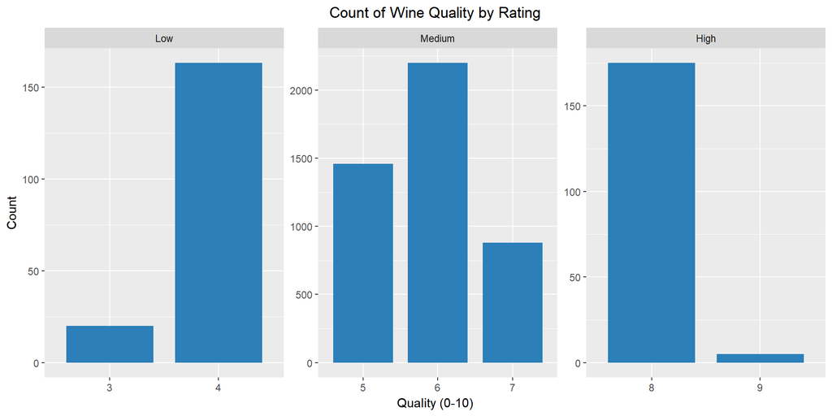

### Description One

The bar plot of quality shows that most of the quality is distributed in  
the Medium range (5-7 rating) while there are few observations that are  
rated as low or high.

### Plot Two

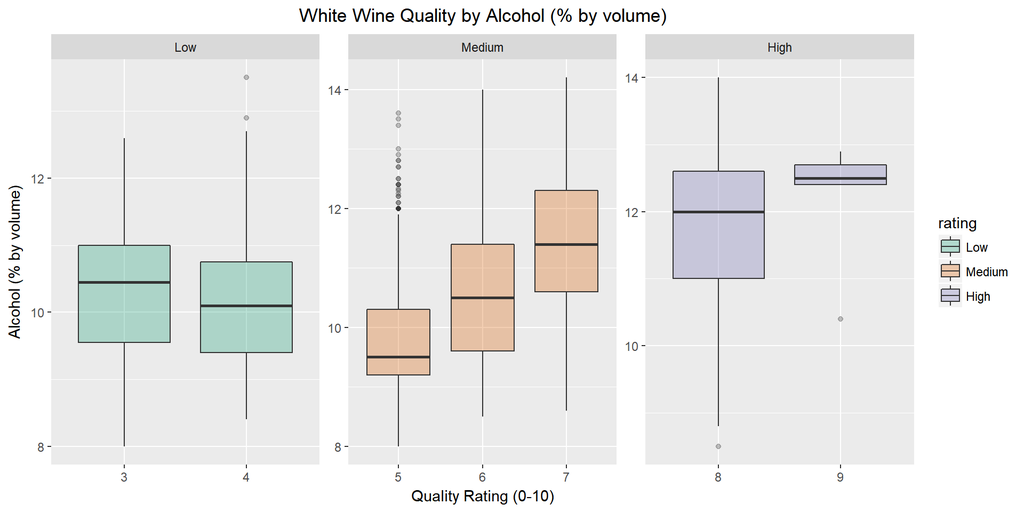

### Description Two

Looking at the main feature of interest (Quality) correlation with Alcohol,  
The plot shows that the ratings of wine is higher for higher alcohol level.  
The plot also explains the positive correlation of 0.44 between quality and  
alcohol

### Plot Three

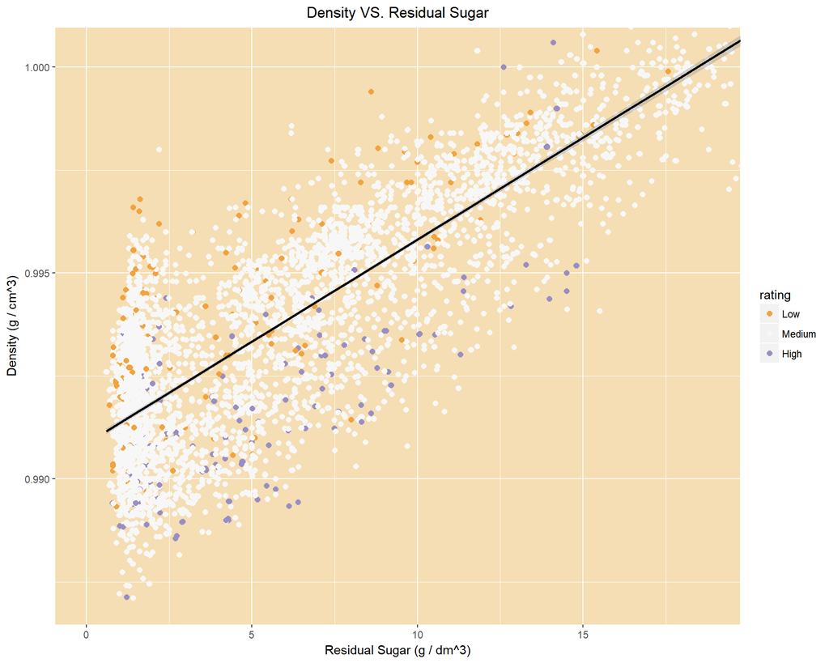

### Description Three

The “Density VS. Residual Sugar” plot shows that there is a linear  
relationship between the density and residual sugar, which explains the  
strength of correlation factor between the two features (+0.84). The higher  
the density, the higher residual sugar exist in white wine.

In addition, a very intersting insight from the same plot that is most of  
the high quality of wine has less density and hense less residual sugar which  
means that sweetness in wine is not of a good quality feature.

# Reflection

> In this project, I have experienced the exploratory data analysis process  
> by exploring the White Wine dataset which consist of 4898 observations  
> and 13 variables.

> **Exploration Findings:**

> > The quality of wine varies from 3 to 9 in our dataset. There are no 0 or 10  
> > rated wine in the dataset, the minimum rated wine is 3 and the maximum is 9.  
> > The median quality is 6 and there are very few wine records that are rated as  
> > 3 or 9 (25 records out of the whole dataset).

> > Most of the quality is distributed in the Medium range (5-7 rating) while  
> > there are few observations that are rated as low or high.

> > The most strong (postivie) correlation is between Density and Residual  
> > Sugar with a correlation of 0.84 while the most strong (negative) correlation is  
> > between Density and Alcohol with a correlation of 0.78.

> > Looking at the main feature of interest (Quality) correlation with other  
> > features, the most strong correlation relationship is with Alcohol which has a  
> > correlation of 0.44.

> > The R-squared value generated by the model is 0.21. This means that about  
> > 21% of wine quality is due to the levels of alcohol, residual sugar, and  
> > density. The generated model is weak and indicates that there are other factors  
> > that affect the quality of wine other than the 3 features tested in the model.

> It was surprizing that the high quality of wine has less residual sugar which  
> means that sweetness in wine is not of a good quality feature although I was  
> thinking that the sweeter the better.

> I have learned a lot in this experience of exploration about visualising and  
> summarizing data using R. I have also learned that right plot scaling makes huge  
> differences when interpreting plots and summarizing findings although I did  
> strugle at the begining when it comes to finding the right scales and getting  
> the plots to show what I intended to.

> I think a future work to this dataset can be adding another feature that has  
> a strong correlation with quality other than Alcohol which is the only  
> correlatable feature (with quality) in this dataset. This would provide a  
> deeper experience with correlation and coming up with more findings.

> **Below References were very useful throughout the project work**

> [1- Visualize Correlation](http://www.sthda.com/english/wiki/visualize-corre%20lation-matrix-using-correlogram)

> [2- Corrplot Tilte Position](https://stackoverflow.com/questions/40509217/how-%20to-have-r-corrplot-title-position-correct)

> [3- Linear Models in R](http://data.princeton.edu/R/linearModels.html)

> [4- Regression](https://www.statmethods.net/stats/regression.html)

> [5- Linear Modeling in R](http://blog.yhat.com/posts/r-lm-summary.html)